# Assignment 5

Ryan Johnson

10/6/2020

## Description

In this exercise, I will estimate more regression models to predict the values of one of my continuous variables, monthly rent (**RNTP**), based on the values of the other variables.

These independent variables are:

1. Annual household income (**HINCP**)
2. Number of bedrooms (**BDSP**)
3. Decade of construction (**BLDG_AGE_dec**)
4. Household type (**HHT_2**)
5. Household size (**NP**)

## Original linear regression model

In my first linear regression model, I only analyzed the first 4 of my 5 independent variables. I excluded household size because it appeared to have an outsize impact on my model fit value, as it is a 1:1 correlation with the single-occupant household value of household type (**HHT_2**).

```r
hh_data_a3 <- read.csv("TravisHH.csv") %>%
  mutate(HHT_2 = case_when(
    HHT_label=="Married couple household"~"Married couple",
    HHT_label=="Other family household: Female householder, no spouse present"~"Single parent family",
    HHT_label=="Other family household: Male householder, no spouse present"~"Single parent family",
    HHT_label=="Nonfamily household: Male householder: Not living alone"~"Non-family multiple",
    HHT_label=="Nonfamily household: Female householder: Not living alone"~"Non-family multiple",
    HHT_label=="Nonfamily household: Female householder: Living alone"~"Single occupant",
    HHT_label=="Nonfamily household: Male householder: Living alone"~"Single occupant"))

model1 <- lm(RNTP ~ HINCP + BDSP + BLDG_AGE_dec + HHT_2,
             data = hh_data_a3)

summary(model1)
```

```
##
## Call:
## lm(formula = RNTP ~ HINCP + BDSP + BLDG_AGE_dec + HHT_2, data = hh_data_a3)
##
## Residuals:
##      Min       1Q   Median       3Q      Max
## -2314.18  -226.25   -18.54   211.74  2140.62
##
## Coefficients:
##                                Estimate    Std. Error t value     Pr(>|t|)
## (Intercept)               1152.21059855   67.26298684  17.130      < 2e-16 ***
## HINCP                        0.00183933    0.00009875  18.626      < 2e-16 ***
## BDSP                       124.05191233    8.22880729  15.075      < 2e-16 ***
## BLDG_AGE_dec1950s         -115.08210508   73.35720166  -1.569      0.11678
## BLDG_AGE_dec1960s         -333.47993494   68.99333575  -4.834 0.0000013947 ***
## BLDG_AGE_dec1970s         -350.19488553   65.48086533  -5.348 0.0000000942 ***
## BLDG_AGE_dec1980s         -358.38196226   64.99686287  -5.514 0.0000000375 ***
## BLDG_AGE_dec1990s         -258.29990264   65.43573634  -3.947 0.0000804459 ***
## BLDG_AGE_dec2000s         -190.81777228   65.63540480  -2.907      0.00367 **
## BLDG_AGE_dec2010s          -94.51893041   65.96175251  -1.433      0.15196
## BLDG_AGE_decpre-1940s     -287.41811535   79.04543168  -3.636      0.00028 ***
## HHT_2Non-family multiple    63.51164579   20.05351653   3.167      0.00155 **
## HHT_2Single occupant       -12.16461624   23.31122765  -0.522      0.60182
## HHT_2Single parent family  -98.10395069   21.12726754  -4.643 0.0000035423 ***
## ---
## Signif. codes:  0 '***' 0.001 '**' 0.01 '*' 0.05 '.' 0.1 ' ' 1
##
## Residual standard error: 464.8 on 3784 degrees of freedom
## Multiple R-squared:  0.2412, Adjusted R-squared:  0.2386
## F-statistic:  92.5 on 13 and 3784 DF,  p-value: < 2.2e-16
```

Below, we can see the impact of the added household size (**NP**) variable. I will call this model #2.

```r
model2 <- lm(RNTP ~ HINCP + BDSP + BLDG_AGE_dec + NP + HHT_2,
             data = hh_data_a3)

summary(model2)
```

```
##
## Call:
## lm(formula = RNTP ~ HINCP + BDSP + BLDG_AGE_dec + NP + HHT_2,
##     data = hh_data_a3)
##
## Residuals:
##      Min       1Q   Median       3Q      Max
## -1966.43  -239.57   -11.39   215.33  2206.11
##
## Coefficients:
##                               Estimate   Std. Error t value      Pr(>|t|)
## (Intercept)               1355.5578513   63.0202419  21.510       < 2e-16 ***
## HINCP                        0.0021697    0.0000927  23.406       < 2e-16 ***
## BDSP                       201.6216485    8.2696711  24.381       < 2e-16 ***
## BLDG_AGE_dec1950s          -58.0858177   68.1739572  -0.852      0.394255
## BLDG_AGE_dec1960s         -337.5231813   64.0814923  -5.267 0.00000014632 ***
## BLDG_AGE_dec1970s         -272.7938902   60.9004613  -4.479 0.00000770856 ***
## BLDG_AGE_dec1980s         -292.7877374   60.4283756  -4.845 0.00000131554 ***
## BLDG_AGE_dec1990s         -227.2001787   60.7901551  -3.737      0.000189 ***
## BLDG_AGE_dec2000s         -147.5615584   60.9878515  -2.420      0.015588 *
## BLDG_AGE_dec2010s          -55.4357680   61.2861927  -0.905      0.365767
## BLDG_AGE_decpre-1940s     -270.7497356   73.4208431  -3.688      0.000230 ***
## NP                        -121.2459806    4.9360955 -24.563       < 2e-16 ***
## HHT_2Non-family multiple   -62.1770375   19.3158790  -3.219      0.001297 **
## HHT_2Single occupant      -249.6405641   23.7120204 -10.528       < 2e-16 ***
## HHT_2Single parent family -115.2902857   19.6355589  -5.872 0.00000000469 ***
## ---
## Signif. codes:  0 '***' 0.001 '**' 0.01 '*' 0.05 '.' 0.1 ' ' 1
##
## Residual standard error: 431.7 on 3783 degrees of freedom
## Multiple R-squared:  0.3455, Adjusted R-squared:  0.3431
## F-statistic: 142.7 on 14 and 3783 DF,  p-value: < 2.2e-16
```

The most notable difference occurs in the apparent model fit, as including the NP variable boosts the adjusted R-squared value from 0.239 to 0.343. Additionally, including NP reduces the significance of the relationship between a date of construction in the 2000s (**BLDG_AGE_dec$2000s**) and monthly rent (**RNTP**). As such, I will continue to exclude this variable from my other models.

## Log-transformed variable

First, I would like to run a model including a log-transformed version of my household income variable (**HINCP**). This is model #3.

```r
model3 <- lm(RNTP ~ log(HINCP) + BDSP + BLDG_AGE_dec + HHT_2,
             data = hh_data_a3)

summary(model3)
```

```
##
## Call:
## lm(formula = RNTP ~ log(HINCP) + BDSP + BLDG_AGE_dec + HHT_2,
##     data = hh_data_a3)
##
## Residuals:
##      Min       1Q   Median       3Q      Max
## -1826.14  -247.09   -26.14   207.46  2136.05
##
## Coefficients:
##                           Estimate Std. Error t value    Pr(>|t|)
## (Intercept)               -530.210    107.051  -4.953 0.000000763 ***
## log(HINCP)                 163.995      7.764  21.123     < 2e-16 ***
## BDSP                       126.018      8.078  15.600     < 2e-16 ***
## BLDG_AGE_dec1950s          -91.915     72.500  -1.268    0.204951
## BLDG_AGE_dec1960s         -308.736     68.198  -4.527 0.000006166 ***
## BLDG_AGE_dec1970s         -334.931     64.719  -5.175 0.000000239 ***
## BLDG_AGE_dec1980s         -330.727     64.262  -5.147 0.000000279 ***
## BLDG_AGE_dec1990s         -232.973     64.674  -3.602    0.000320 ***
## BLDG_AGE_dec2000s         -137.038     64.821  -2.114    0.034572 *
## BLDG_AGE_dec2010s          -53.436     65.147  -0.820    0.412134
## BLDG_AGE_decpre-1940s     -249.989     78.162  -3.198    0.001394 **
## HHT_2Non-family multiple    77.098     19.822   3.889    0.000102 ***
## HHT_2Single occupant        15.998     23.183   0.690    0.490183
## HHT_2Single parent family  -88.568     20.900  -4.238 0.000023109 ***
## ---
## Signif. codes:  0 '***' 0.001 '**' 0.01 '*' 0.05 '.' 0.1 ' ' 1
##
## Residual standard error: 459.3 on 3784 degrees of freedom
## Multiple R-squared:  0.259,  Adjusted R-squared:  0.2564
## F-statistic: 101.7 on 13 and 3784 DF,  p-value: < 2.2e-16
```

## Converting a continuous variable to a categorical

Instead of log-transforming household income (**HINCP**), I would like to convert it to a categorical variable. It may be that income groupings behave differently with regard to rent; especially considering that my rent data appears capped at $3000/month, and so very-high-incomes cannot pay proportionally more rent, this may more accurately reflect behaviors of the subject population. We can examine this in model #4.

```r
hh_data_a3 <- hh_data_a3 %>%
  mutate(income_lvl = case_when(HINCP <= 25000 ~ "1Low income",
                                (HINCP > 25000) & (HINCP < 100000) ~ "Moderate income",
                                HINCP >= 100000 ~ "High income"))

model4 <- lm(RNTP ~ income_lvl + BDSP + BLDG_AGE_dec + HHT_2,
            data = hh_data_a3)

summary(model4)
```

```
##
## Call:
## lm(formula = RNTP ~ income_lvl + BDSP + BLDG_AGE_dec + HHT_2,
##     data = hh_data_a3)
##
## Residuals:
##     Min      1Q  Median      3Q     Max
## -1689.3  -244.9   -24.3   203.1  2125.5
##
## Coefficients:
##                           Estimate Std. Error t value    Pr(>|t|)
## (Intercept)               1032.096     67.998  15.178     < 2e-16 ***
## income_lvlHigh income      489.726     23.819  20.561     < 2e-16 ***
## income_lvlModerate income  182.250     20.189   9.027     < 2e-16 ***
## BDSP                       127.053      8.056  15.772     < 2e-16 ***
## BLDG_AGE_dec1950s         -144.564     72.417  -1.996    0.045976 *
## BLDG_AGE_dec1960s         -301.521     68.113  -4.427 0.000009834 ***
## BLDG_AGE_dec1970s         -333.582     64.636  -5.161 0.000000258 ***
## BLDG_AGE_dec1980s         -339.991     64.162  -5.299 0.000000123 ***
## BLDG_AGE_dec1990s         -243.464     64.578  -3.770    0.000166 ***
## BLDG_AGE_dec2000s         -148.998     64.730  -2.302    0.021398 *
## BLDG_AGE_dec2010s          -61.396     65.059  -0.944    0.345388
## BLDG_AGE_decpre-1940s     -248.635     78.074  -3.185    0.001461 **
## HHT_2Non-family multiple    63.614     19.807   3.212    0.001331 **
## HHT_2Single occupant        16.866     23.150   0.729    0.466304
## HHT_2Single parent family  -87.115     20.877  -4.173 0.000030758 ***
## ---
## Signif. codes:  0 '***' 0.001 '**' 0.01 '*' 0.05 '.' 0.1 ' ' 1
##
## Residual standard error: 458.7 on 3783 degrees of freedom
## Multiple R-squared:  0.2612, Adjusted R-squared:  0.2585
## F-statistic: 95.54 on 14 and 3783 DF,  p-value: < 2.2e-16
```

As indicated by the adjusted R-squared value of 0.259, vs 0.256 for the log-adjusted income model, this model including three categorical income levels has a slightly better model fit. According to the model, those households with high annual incomes (above $100,000) and moderate annual incomes (between $25,000 and $100,000) pay about $490 and $182 more in monthly rent, respectively.

## Interaction term

Perhaps the effect of annual household income is different depending on the type of household - it may be that a single occupant household can afford more rent as compared to a similarly-situated household of unmarried people, whose household income must cover the personal expenses of multiple people.

In this model, I will test the interaction between these variables, using model #3 as the framework. This new model will be model #5.

```r
model5 <- lm(RNTP ~ log(HINCP) + BDSP + BLDG_AGE_dec + HHT_2 + log(HINCP):HHT_2,
             data = hh_data_a3)

summary(model5)
```

```
##
## Call:
## lm(formula = RNTP ~ log(HINCP) + BDSP + BLDG_AGE_dec + HHT_2 +
##     log(HINCP):HHT_2, data = hh_data_a3)
##
## Residuals:
##     Min      1Q  Median      3Q     Max
## -1632.0  -247.0   -24.6   200.4  2118.8
##
## Coefficients:
##                                       Estimate Std. Error t value Pr(>|t|)
## (Intercept)                          -1252.518    165.080  -7.587 4.09e-14 ***
## log(HINCP)                             228.190     13.754  16.590  < 2e-16 ***
## BDSP                                   125.460      8.006  15.671  < 2e-16 ***
## BLDG_AGE_dec1950s                      -72.057     71.786  -1.004 0.315548
## BLDG_AGE_dec1960s                     -296.118     67.512  -4.386 1.19e-05 ***
## BLDG_AGE_dec1970s                     -318.514     64.079  -4.971 6.97e-07 ***
## BLDG_AGE_dec1980s                     -310.591     63.640  -4.880 1.10e-06 ***
## BLDG_AGE_dec1990s                     -229.589     64.010  -3.587 0.000339 ***
## BLDG_AGE_dec2000s                     -145.098     64.162  -2.261 0.023789 *
## BLDG_AGE_dec2010s                      -31.662     64.552  -0.490 0.623811
## BLDG_AGE_decpre-1940s                 -234.473     77.392  -3.030 0.002465 **
## HHT_2Non-family multiple              1792.894    215.363   8.325  < 2e-16 ***
## HHT_2Single occupant                   973.807    233.904   4.163 3.21e-05 ***
## HHT_2Single parent family              -99.057    239.544  -0.414 0.679246
## log(HINCP):HHT_2Non-family multiple   -155.277     19.394  -8.007 1.56e-15 ***
## log(HINCP):HHT_2Single occupant        -87.919     21.834  -4.027 5.77e-05 ***
## log(HINCP):HHT_2Single parent family     3.127     21.936   0.143 0.886645
## ---
## Signif. codes:  0 '***' 0.001 '**' 0.01 '*' 0.05 '.' 0.1 ' ' 1
##
## Residual standard error: 454.6 on 3781 degrees of freedom
## Multiple R-squared:  0.2747, Adjusted R-squared:  0.2717
## F-statistic: 89.52 on 16 and 3781 DF,  p-value: < 2.2e-16
```

We see from the interaction term that higher household income has a positive statistically significant effect on monthly rents, but that the effect of increased income is less for single-occupant and non-family households compared to married couple households. The coefficient estimate for the interaction between increased income and single-parent family households (as compared to the effect of increased income on married couple households) is not statistically significant.

## Conclusion and visualization

In conclusion, model #5 (which included the log of annual household income and an interaction term between income and household type) offered the best model fit, with an adjusted R-squared value of 0.2717.

While model #2 has the highest R-squared value, this is deceptively inflated by the household size variable (**NP**), which in the case of single-occupant households is naturally perfectly correlated to the household type (**HHT_2**) variable.

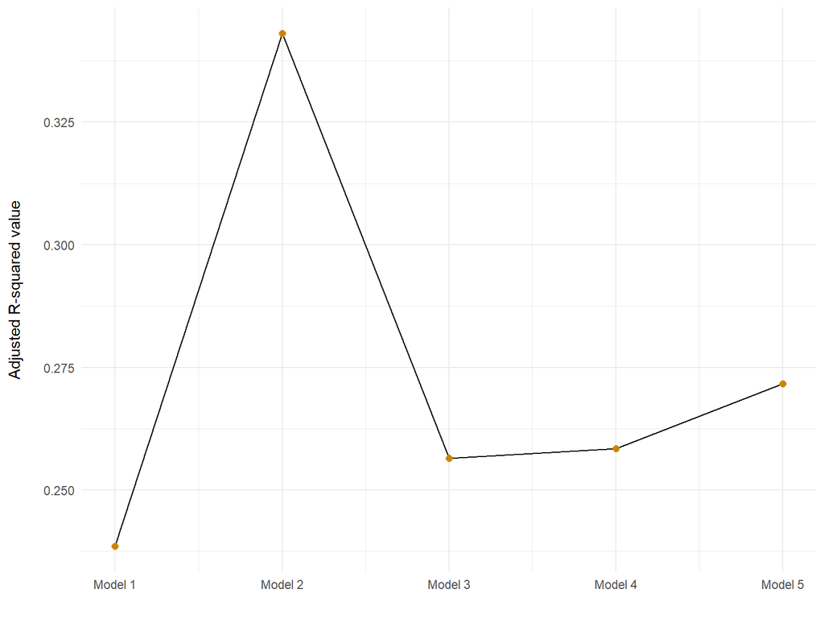

```r
ModelFit <- tibble(model = c(1, 2, 3, 4, 5),
                   R_square = c(summary(model1)$adj.r.squared,
                                summary(model2)$adj.r.squared,
                                summary(model3)$adj.r.squared,
                                summary(model4)$adj.r.squared,
                                summary(model5)$adj.r.squared))

ggplot(ModelFit, aes(x = model, y = R_square)) +
  geom_line() +
  geom_point(data = ModelFit, aes(x = model, y = R_square),
             size = 2,
             color = "orange3") +
  scale_x_continuous(name = "",
                     breaks = breaks <- seq(1, 5, by = 1),
                     labels = paste("Model", breaks)) +
  scale_y_continuous(name = "Adjusted R-squared value\n") +
  theme_minimal()
```

The results of models 1, 3, and 5 can be seen together in the table below. The coefficient for (**HINCP**) in model 1 appears to be zero due to rounding, but is in fact 0.0018.

```r
coeff_names <- c("Annual household income" = "HINCP",
                 "Annual household income\n(log-transformed)" =
                   "log(HINCP)",
                 "Built pre-1940s\n(compared to 1940s)" =
                   "BLDG_AGE_decpre-1940s",
                 "Built 1950s\n(compared to 1940s)" =
                   "BLDG_AGE_dec1950s",
                 "Built 1960s\n(compared to 1940s)" =
                   "BLDG_AGE_dec1960s",
                 "Built 1970s\n(compared to 1940s)" =
                   "BLDG_AGE_dec1970s",
                 "Built 1980s\n(compared to 1940s)" =
                   "BLDG_AGE_dec1980s",
                 "Built 1990s\n(compared to 1940s)" =
                   "BLDG_AGE_dec1990s",
                 "Built 2000s\n(compared to 1940s)" =
                   "BLDG_AGE_dec2000s",
                 "Built 2010s\n(compared to 1940s)" =
                   "BLDG_AGE_dec2010s",
                 "Single-parent family\nhousehold (compared to married)" =
                   "HHT_2Single parent family",
                 "Non-family multiple-member\nhousehold (compared to married)" =
                   "HHT_2Non-family multiple",
                 "Single occupant\nhousehold (compared to married)" =
                   "HHT_2Single occupant",
                 "Interaction:\nincome and single-parent family" =
                   "log(HINCP):HHT_2Single parent family",
                 "Interaction:\nincome and non-family multiple" =
                   "log(HINCP):HHT_2Non-family multiple",
                 "Interaction:\nincome and single occupant" =
                   "log(HINCP):HHT_2Single occupant")

export_summs(model1, model3, model5,
             error_format = "(p = {p.value})",
             error_pos = "same",
             model.names = c("Initial model", "Model 3", "Preferred model"),
             coefs = coeff_names)
```

|  | Initial model | Model 3 | Preferred model |
| --- | --- | --- | --- |
| Annual household income | 0.00 *** (p = 0.00) |  |  |
| Annual household income (log-transformed) |  | 164.00 *** (p = 0.00) | 228.19 *** (p = 0.00) |
| Built pre-1940s (compared to 1940s) | -287.42 *** (p = 0.00) | -249.99 ** (p = 0.00) | -234.47 ** (p = 0.00) |
| Built 1950s (compared to 1940s) | -115.08 (p = 0.12) | -91.91 (p = 0.20) | -72.06 (p = 0.32) |
| Built 1960s (compared to 1940s) | -333.48 *** (p = 0.00) | -308.74 *** (p = 0.00) | -296.12 *** (p = 0.00) |
| Built 1970s (compared to 1940s) | -350.19 *** (p = 0.00) | -334.93 *** (p = 0.00) | -318.51 *** (p = 0.00) |
| Built 1980s (compared to 1940s) | -358.38 *** (p = 0.00) | -330.73 *** (p = 0.00) | -310.59 *** (p = 0.00) |
| Built 1990s (compared to 1940s) | -258.30 *** (p = 0.00) | -232.97 *** (p = 0.00) | -229.59 *** (p = 0.00) |
| Built 2000s (compared to 1940s) | -190.82 ** (p = 0.00) | -137.04 * (p = 0.03) | -145.10 * (p = 0.02) |
| Built 2010s (compared to 1940s) | -94.52 (p = 0.15) | -53.44 (p = 0.41) | -31.66 (p = 0.62) |
| Single-parent family household (compared to married) | -98.10 *** (p = 0.00) | -88.57 *** (p = 0.00) | -99.06 (p = 0.68) |
| Non-family multiple-member household (compared to married) | 63.51 ** (p = 0.00) | 77.10 *** (p = 0.00) | 1792.89 *** (p = 0.00) |
| Single occupant household (compared to married) | -12.16 (p = 0.60) | 16.00 (p = 0.49) | 973.81 *** (p = 0.00) |
| Interaction: income and single-parent family |  |  | 3.13 (p = 0.89) |
| Interaction: income and non-family multiple |  |  | -155.28 *** (p = 0.00) |
| Interaction: income and single occupant |  |  | -87.92 *** (p = 0.00) |
| N | 3798 | 3798 | 3798 |
| R2 | 0.24 | 0.26 | 0.27 |
| *** p < 0.001; ** p < 0.01; * p < 0.05. |  |  |  |

Finally, I’d like to visualize the predicted relationship between monthly rent and income, accounting for household type (the interaction term added to Model #5). I exclude the confidence intervals for the sake of visual clarity.

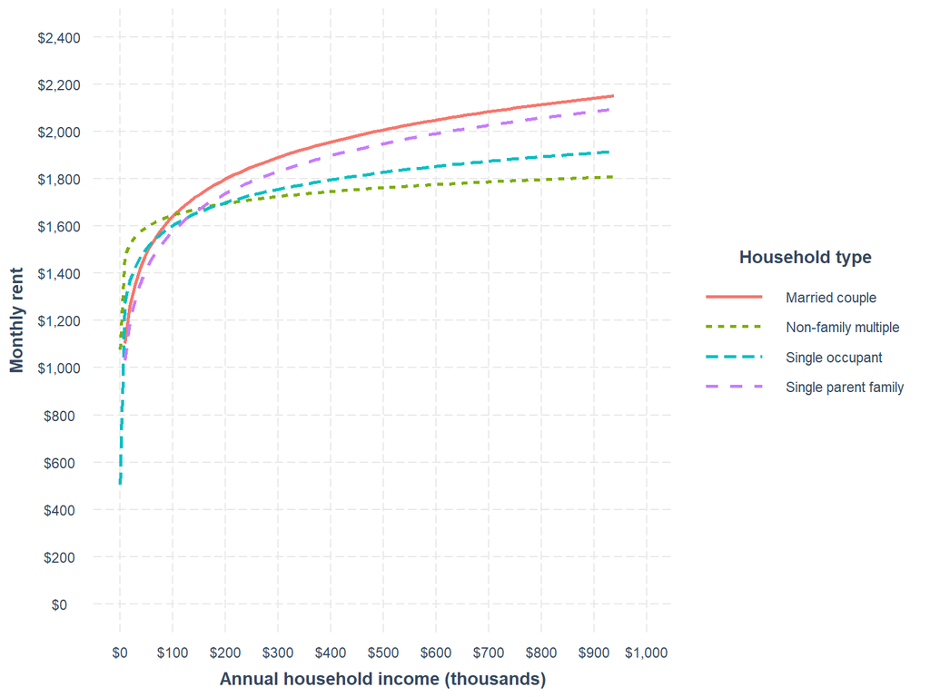

```r
interact_plot(model5, pred = HINCP, modx = HHT_2, interval = FALSE) +
  scale_x_continuous(name = "Annual household income (thousands)",
                     limits = c(0, 1000000),
                     breaks = breaks <- seq(0, 1000000, by = 100000),
                     labels = paste("$",
                                    prettyNum(breaks/1000,
                                              big.mark = ","),
                                    sep = "")) +
  scale_y_continuous(name = "Monthly rent",
                     limits = c(0, 2400),
                     breaks = breaks <- seq(0, 2400, by = 200),
                     labels = paste("$",
                                    prettyNum(breaks,
                                              big.mark = ","),
                                    sep = "")) +

  scale_color_discrete(name = "Household type") +
  scale_linetype_discrete(name = "Household type") +
  scale_fill_discrete(name = "")
```